# Time Series Analysis

Ad Campaign Metrics

Suhas Srinivasan

### Section 1

#### Exploratory Data Analysis

```r
library(stringr)
ad_table = read.csv('./ad_table.csv')
cat('\nAd table dimensiions: ', dim(ad_table), '\n\n')
```

```
##
## Ad table dimensiions:  2115 7
```

```r
summary(ad_table)
```

```
##          date          shown           clicked        converted
##  2015-10-01:  40   Min.   :     0   Min.   :    0   Min.   :   0.0
##  2015-10-02:  40   1st Qu.: 28031   1st Qu.:  744   1st Qu.:  18.0
##  2015-10-04:  40   Median : 54029   Median : 1392   Median :  41.0
##  2015-10-05:  40   Mean   : 68300   Mean   : 3056   Mean   : 126.5
##  2015-10-06:  40   3rd Qu.: 97315   3rd Qu.: 3366   3rd Qu.: 103.0
##  2015-10-07:  40   Max.   :192507   Max.   :20848   Max.   :1578.0
##  (Other)   :1875
##  avg_cost_per_click total_revenue               ad
##  Min.   :0.000      Min.   : -200.2   ad_group_1 :  53
##  1st Qu.:0.760      1st Qu.:  235.5   ad_group_11:  53
##  Median :1.400      Median :  553.3   ad_group_12:  53
##  Mean   :1.374      Mean   : 1966.5   ad_group_13:  53
##  3rd Qu.:1.920      3rd Qu.: 1611.5   ad_group_15:  53
##  Max.   :4.190      Max.   :39623.7   ad_group_16:  53
##                                       (Other)    :1797
```

```r
ad_table$date = as.Date(ad_table$date)

# Convert ad group to a numberic column and remove redundant label pattern
colnames(ad_table)[7] = "ad_group"
ad_table$ad_group = as.character(ad_table$ad_group)
for(i in 1:nrow(ad_table)) {
  temp = ad_table[i, 7]
  Split = str_split(temp, "_")
  num  = sapply(Split, tail, 1)
  ad_table[i, 7] = num
}
ad_table$ad_group = as.numeric(ad_table$ad_group)
head(ad_table, 5)
```

|  | date | shown | clicked | converted | avg_cost_per_click | total_revenue | ad_group |
| --- | --- | --- | --- | --- | --- | --- | --- |
| 1 | 2015-10-01 | 65877 | 2339 | 43 | 0.90 | 641.62 | 1 |
| 2 | 2015-10-02 | 65100 | 2498 | 38 | 0.94 | 756.37 | 1 |
| 3 | 2015-10-03 | 70658 | 2313 | 49 | 0.86 | 970.90 | 1 |
| 4 | 2015-10-04 | 69809 | 2833 | 51 | 1.01 | 907.39 | 1 |
| 5 | 2015-10-05 | 68186 | 2696 | 41 | 1.00 | 879.45 | 1 |

```r
# Create a copy so that original data order is not altered
copy_at1 = subset(ad_table, select = -c(date))

# Aggregate all values by ad group
copy_at1 = aggregate(. ~ ad_group, copy_at1, sum)
summary(copy_at1)
```

```
##     ad_group         shown            clicked         converted
##  Min.   : 1.00   Min.   : 439977   Min.   : 13104   Min.   :    0.0
##  1st Qu.:10.75   1st Qu.:1501301   1st Qu.: 41065   1st Qu.:  985.2
##  Median :20.50   Median :2840794   Median : 69951   Median : 2343.5
##  Mean   :20.50   Mean   :3611354   Mean   :161590   Mean   : 6686.2
##  3rd Qu.:30.25   3rd Qu.:5129424   3rd Qu.:175179   3rd Qu.: 5274.8
##  Max.   :40.00   Max.   :9274262   Max.   :851886   Max.   :66741.0
##  avg_cost_per_click total_revenue
##  Min.   :  4.91     Min.   :      0
##  1st Qu.: 41.84     1st Qu.:  14136
##  Median : 78.97     Median :  35647
##  Mean   : 72.64     Mean   : 103980
##  3rd Qu.:102.84     3rd Qu.:  77211
##  Max.   :165.55     Max.   :1054962
```

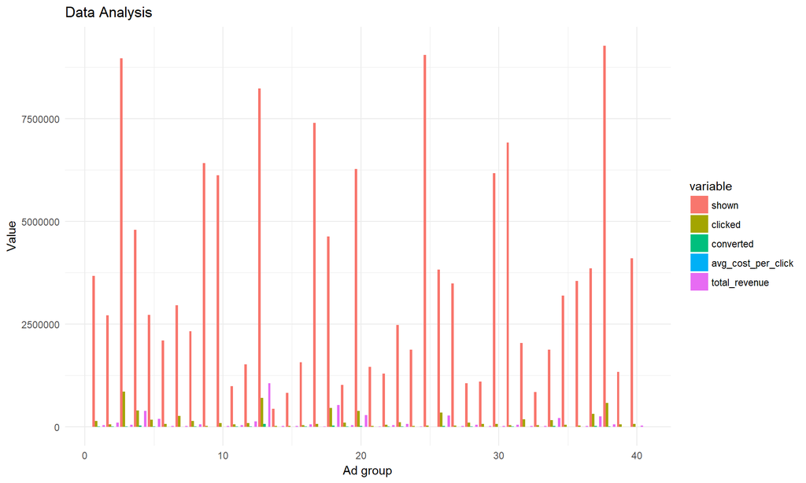

```r
library(reshape2)
library(ggplot2)

df1 = melt(copy_at1, id.vars = c("ad_group"))
ga = ggplot(df1, aes(ad_group, value, fill = variable)) +
    geom_bar(stat = 'identity',position=position_dodge()) +
    theme_minimal() +
    labs(title="Data Analysis", x="Ad group", y = "Value")
ga
```

### Section 2

#### Identify 5 best ad groups

Considering *Total Revenue* and a new metric, *Profit*, to find the best performaing ad groups.

We will use the aggregated data to compute Profit for each ad group, given by below equation.

$Profit = Total\ revenue - (Avg.\ cost\ per\ click\ *\ No.\ of\ ads\ clicked)$

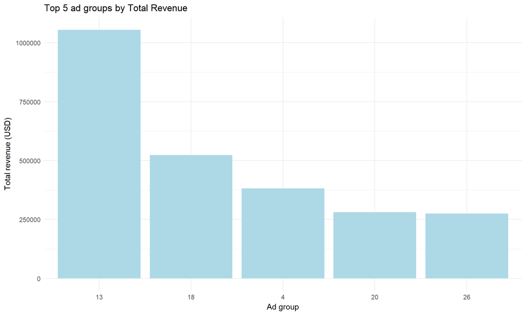

```r
# Order data frame by Revenue in descending order and select top 5 ad groups.
copy_at2 = copy_at1[order(copy_at1$total_revenue, decreasing = T), ]
df2 = subset(copy_at2, select = c(ad_group, total_revenue))
df2 = df2[1:5, ]
gb = ggplot(df2, aes(x = reorder(ad_group, -total_revenue), y = total_revenue)) +
    geom_bar(stat='identity', fill="lightblue") +
    theme_minimal() +
    labs(title="Top 5 ad groups by Total Revenue", x="Ad group", y = "Total revenue (USD)")
gb
```

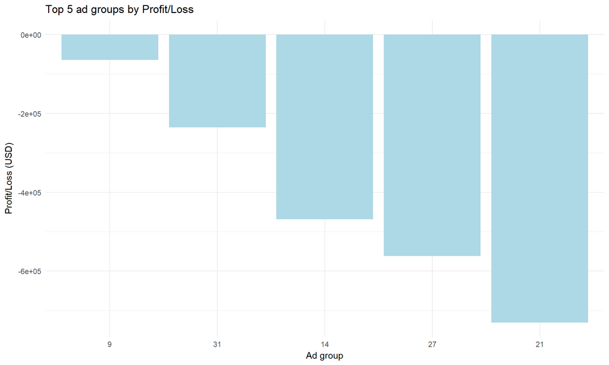

```r
# Calculate Profit and order in descending order to select top 5 ad groups.
copy_at2$profit = copy_at2$total_revenue-(copy_at2$avg_cost_per_click * copy_at2$clicked)
copy_at2 = copy_at2[order(copy_at2$profit, decreasing = T), ]
df3 = subset(copy_at2, select = c(ad_group, profit))
df3 = df3[1:5, ]
gc = ggplot(df3, aes(x = reorder(ad_group, -profit), y = profit)) +
    geom_bar(stat='identity', fill="lightblue") +
    theme_minimal() +
    labs(title="Top 5 ad groups by Profit/Loss", x="Ad group", y = "Profit/Loss (USD)")
gc
```

### Section 3

#### For each ad group predict how many ads will be shown on Dec 15

#### Section 3.1

First let us visualize the ads shown by each ad group as a time-series.

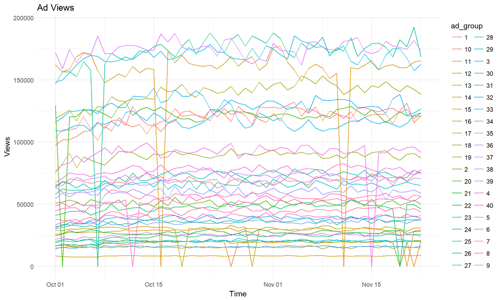

```r
# Use the original ad table to get date, ads shown and ad group.
copy_at3 = subset(ad_table, select = c(date, shown, ad_group))

# Visualize the current ad views trends by ad group
df4 = melt(copy_at3, id.vars="date", measure.vars="shown", variable.name = "ad_group")
df4$ad_group = as.character(copy_at3$ad_group)
gd = ggplot(df4, aes(x=date, y=value, colour=ad_group, group=ad_group)) +
    geom_line() +
    theme_minimal() +
    labs(title="Ad Views", x="Time", y = "Views")
gd
```

#### Section 3.2

There are a few time instances in the above chart when the view is 0 for certain ad groups.  
This could be either due to missing data in *shown* or missing *dates*.  
First we will find the ad groups with missing dates and add back missing dates, these rows will have *shown* set to 0.  
We will then impute the zero values in *shown* by the average views for a particular ad group. This will help to avoid any problems with time-series modeling.

```r
# Find the ad groups and their indices where views are zero
copy_at4 = subset(ad_table, select = c(date, shown, ad_group))

# Find dates
ad_list = unique(copy_at4$ad_group)
prev_dates = 0
mis_grps = c()
for(ad in ad_list) {
  dates = length(copy_at4[copy_at4$ad_group == ad, "date"])
  if(dates < prev_dates) {
    mis_grps = c(mis_grps, ad)
  }
  prev_dates = dates
}
cat("\nAd groups with missing dates are -", mis_grps)
```

```
##
## Ad groups with missing dates are - 10 14 18 20 24
```

```r
# Setup a default list of dates
def_dates = as.Date(copy_at4[copy_at4$ad_group == 1, "date"])
# Get the groups with missing dates
# Find the missing date (these groups are only missing one date)
# Insert the missing date
for(mis in mis_grps) {
  mis_dates = as.Date(copy_at4[copy_at4$ad_group == mis, "date"])
  mdate = as.Date(setdiff(def_dates, mis_dates), origin = "1970-01-01")
  ins_df = data.frame(date = mdate, shown = 0, ad_group = mis)
  copy_at4 = rbind(copy_at4, ins_df)
}

# Order by ad and date
copy_at4 = copy_at4[order(copy_at4[,3], copy_at4[,1] ), ]

# Fix ads shown
zero_list = copy_at4[copy_at4$shown == 0, "ad_group"]
index_list = which(copy_at4$shown == 0)
cat("\nNo. of zero views originally:", length(zero_list))
```

```
##
## No. of zero views originally: 18
```

```r
# Impute the zero views with avg. views for each ad group
# If an ad group is repeated, use a single avg. value to impute
counter = 1
prev_ad = 0
prev_impt = 0
for(ad in zero_list) {
  if(ad == prev_ad) {
    copy_at4$shown[index_list[counter]] = prev_impt
  }
  else {
    views = copy_at4[copy_at4$ad_group == ad, "shown"]
    prev_impt = round(mean(views))
    copy_at4$shown[index_list[counter]] = prev_impt
    prev_ad = ad
  }
  counter = counter + 1
}

zero_list = copy_at4[copy_at4$shown == 0, "ad_group"]
cat("\nNo. of zero views after imputation:", length(zero_list))
```

```
##
## No. of zero views after imputation: 0
```

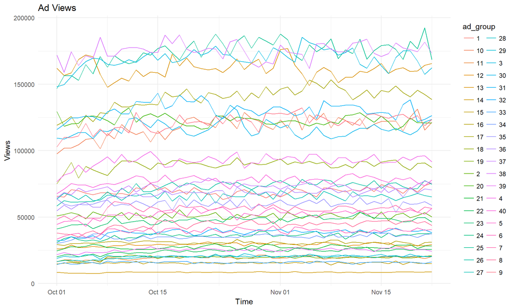

```r
# Visualize the changes
df5 = melt(copy_at4, id.vars="date", measure.vars="shown", variable.name = "ad_group")
df5$ad_group = as.character(copy_at4$ad_group)

ge = ggplot(df5, aes(x=date, y=value, colour=ad_group, group=ad_group)) +
    geom_line() +
    theme_minimal() +
    labs(title="Ad Views", x="Time", y = "Views")
ge
```